# DATA 624: Group 2 Homework

Juliann McEachern

# Assignment 5

Assignment 5 includes problem 7.5, 7.6, and 7.10 from the HA text. The following R packages have been used for completion of all homework assignments to date:

```r
#Textbook Packages
library(fpp2)
library(AppliedPredictiveModeling)
library(mlbench)

#Processing
library(tidyverse)

#Graphing
library(ggplot2)
library(grid)
library(gridExtra)
library(lemon)

#Math
library(caret)
library(forecast)
library(randomForest)
library(seasonal)
library(psych)
library(corrplot)

#Formatting
library(knitr)
library(kableExtra)
```

# 7.5: Data set books contains the daily sales of paperback and hardcover books at the same store. The task is to forecast the next four days’ sales for paperback and hardcover books.

## (a). Plot the series and discuss the main features of the data.

### Timeseries Plot

The `books` data shows an overall positive trend over the 30-day period for paperback and hardcover books. There is heavy fluctuation between days, suggesting seasonality within the time series.

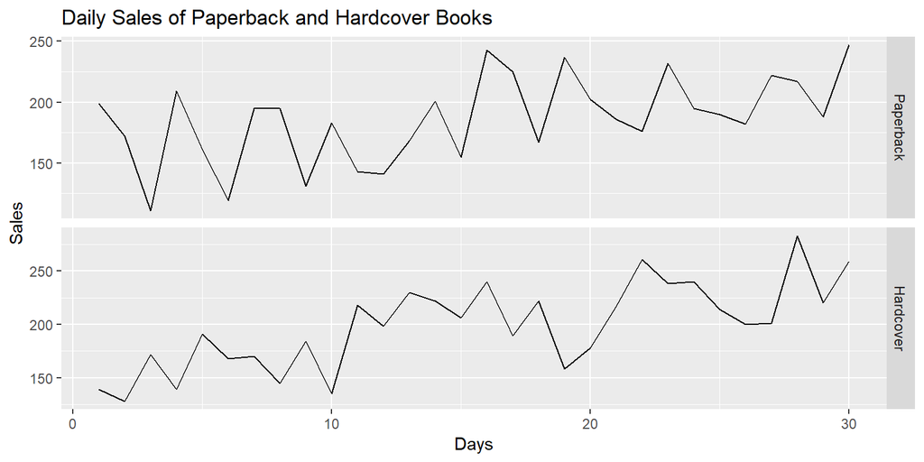

```r
autoplot(books, facet=TRUE) +
  labs(title="Daily Sales of Paperback and Hardcover Books",
       x="Days",
       y="Sales")
```

### Decomposed Plot

We can look at the decomposed timeseries to better understand the trend and seasonality on a weekly basis. Sales tend to peak three times per week and increase throughout the entire month. The paperback books trend increases more drastically between weeks two and four, while hardcover books appear to have smoother incline. Hardcover books also show more fluctuation in the seasonal component.

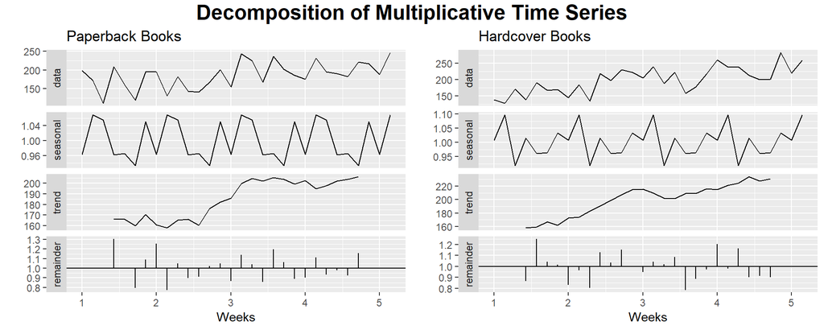

```r
paperback <- books[,1]
hardcover <- books[,2]

pb_plot <- ts(paperback, frequency=7) %>%
  decompose(type="multiplicative") %>%
  autoplot() +
  labs(title = "Paperback Books",
       x = "Weeks")

hc_plot <- ts(hardcover, frequency = 7) %>%
  decompose(type="multiplicative") %>%
  autoplot() +
  labs(title = "Hardcover Books",
       x = "Weeks")

grid.arrange(pb_plot,
             hc_plot,
             ncol = 2,
             top=textGrob("Decomposition of Multiplicative Time Series",
                          gp = gpar(fontface = "bold", cex = 1.5)))
```

## (b). Use the `ses()` function to forecast each series, and plot the forecasts.

### Paperback SES

```r
pb_ses <- ses(paperback, h=4)
summary(pb_ses)
```

```
##
## Forecast method: Simple exponential smoothing
##
## Model Information:
## Simple exponential smoothing
##
## Call:
##  ses(y = paperback, h = 4)
##
##   Smoothing parameters:
##     alpha = 0.1685
##
##   Initial states:
##     l = 170.8271
##
##   sigma:  34.8183
##
##      AIC     AICc      BIC
## 318.9747 319.8978 323.1783
##
## Error measures:
##                    ME     RMSE     MAE       MPE     MAPE      MASE
## Training set 7.175981 33.63769 27.8431 0.4736071 15.57784 0.7021303
##                    ACF1
## Training set -0.2117522
##
## Forecasts:
##    Point Forecast    Lo 80    Hi 80    Lo 95    Hi 95
## 31       207.1097 162.4882 251.7311 138.8670 275.3523
## 32       207.1097 161.8589 252.3604 137.9046 276.3147
## 33       207.1097 161.2382 252.9811 136.9554 277.2639
## 34       207.1097 160.6259 253.5935 136.0188 278.2005
```

### Hardcover SES

```r
hc_ses <- ses(hardcover, h=4)
summary(hc_ses)
```

```
##
## Forecast method: Simple exponential smoothing
##
## Model Information:
## Simple exponential smoothing
##
## Call:
##  ses(y = hardcover, h = 4)
##
##   Smoothing parameters:
##     alpha = 0.3283
##
##   Initial states:
##     l = 149.2861
##
##   sigma:  33.0517
##
##      AIC     AICc      BIC
## 315.8506 316.7737 320.0542
##
## Error measures:
##                    ME     RMSE      MAE      MPE     MAPE      MASE
## Training set 9.166735 31.93101 26.77319 2.636189 13.39487 0.7987887
##                    ACF1
## Training set -0.1417763
##
## Forecasts:
##    Point Forecast    Lo 80    Hi 80    Lo 95    Hi 95
## 31       239.5601 197.2026 281.9176 174.7799 304.3403
## 32       239.5601 194.9788 284.1414 171.3788 307.7414
## 33       239.5601 192.8607 286.2595 168.1396 310.9806
## 34       239.5601 190.8347 288.2855 165.0410 314.0792
```

### Plot

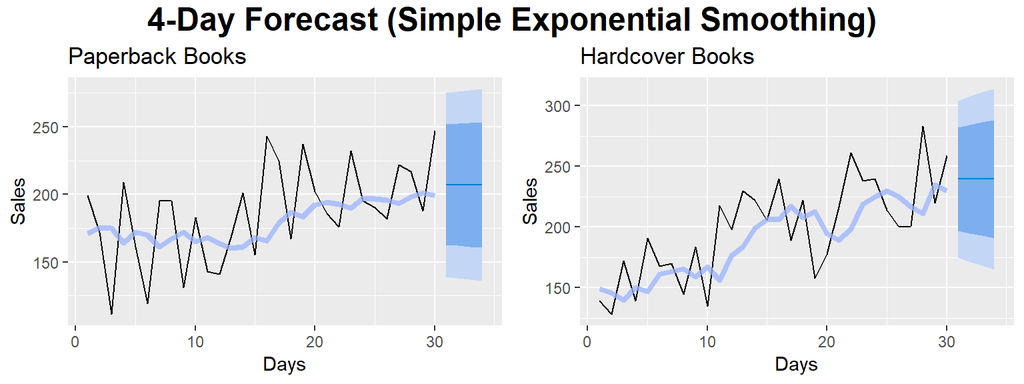

```r
pb_ses_plot <- autoplot(pb_ses, size=1, fcol="#0044cc") +
  autolayer(fitted(pb_ses), series="Fitted", alpha=.75, size=1.5, color="#99b3ff") +
  labs(title="Paperback Books", y="Sales", x="Days")

hc_ses_plot <- autoplot(hc_ses, size=1, fcol="#0044cc") +
  autolayer(fitted(hc_ses), series="Fitted", alpha=.75, size=1.5, color="#99b3ff") +
  labs(title="Hardcover Books", y="Sales", x="Days")

grid.arrange(pb_ses_plot, hc_ses_plot, ncol = 2,
             top=textGrob("4-Day Forecast (Simple Exponential Smoothing)",
                          gp = gpar(fontface = "bold", cex = 1.5)))
```

## (c). Compute the RMSE values for the training data in each case.

The root mean squared error (RMSE) is calculated below and tells us the spread between the residual errors from our predicted and observed using the SES method. The RMSE for paperback books is slightly higher than hardcover, suggesting better accuracy in the later’s predictions.

```r
#manual calculation
sqrt(mean(pb_ses$residuals^2))
sqrt(mean(hc_ses$residuals^2))

#caret package
RMSE(fitted(pb_ses), paperback)
RMSE(fitted(hc_ses), hardcover)
```

RMSE Values for Book Sales Forecast

| paperback | hardcover |
| --- | --- |
| 33.63769 | 31.93101 |

# 7.6: Continuation of exercise 7.5.

## (a). Now apply Holt’s linear method to the `paperback` and `hardback` series and compute four-day forecasts in each case.

### Paperback

```r
pb_holt <- holt(paperback, h=4)
summary(pb_holt)
```

```
##
## Forecast method: Holt's method
##
## Model Information:
## Holt's method
##
## Call:
##  holt(y = paperback, h = 4)
##
##   Smoothing parameters:
##     alpha = 1e-04
##     beta  = 1e-04
##
##   Initial states:
##     l = 170.699
##     b = 1.2621
##
##   sigma:  33.4464
##
##      AIC     AICc      BIC
## 318.3396 320.8396 325.3456
##
## Error measures:
##                     ME     RMSE      MAE       MPE     MAPE      MASE
## Training set -3.717178 31.13692 26.18083 -5.508526 15.58354 0.6602122
##                    ACF1
## Training set -0.1750792
##
## Forecasts:
##    Point Forecast    Lo 80    Hi 80    Lo 95    Hi 95
## 31       209.4668 166.6035 252.3301 143.9130 275.0205
## 32       210.7177 167.8544 253.5811 145.1640 276.2715
## 33       211.9687 169.1054 254.8320 146.4149 277.5225
## 34       213.2197 170.3564 256.0830 147.6659 278.7735
```

### Hardcover

```r
hc_holt <- holt(hardcover, h=4)
summary(hc_holt)
```

```
##
## Forecast method: Holt's method
##
## Model Information:
## Holt's method
##
## Call:
##  holt(y = hardcover, h = 4)
##
##   Smoothing parameters:
##     alpha = 1e-04
##     beta  = 1e-04
##
##   Initial states:
##     l = 147.7935
##     b = 3.303
##
##   sigma:  29.2106
##
##      AIC     AICc      BIC
## 310.2148 312.7148 317.2208
##
## Error measures:
##                      ME     RMSE      MAE       MPE    MAPE      MASE
## Training set -0.1357882 27.19358 23.15557 -2.114792 12.1626 0.6908555
##                     ACF1
## Training set -0.03245186
##
## Forecasts:
##    Point Forecast    Lo 80    Hi 80    Lo 95    Hi 95
## 31       250.1739 212.7390 287.6087 192.9222 307.4256
## 32       253.4765 216.0416 290.9113 196.2248 310.7282
## 33       256.7791 219.3442 294.2140 199.5274 314.0308
## 34       260.0817 222.6468 297.5166 202.8300 317.3334
```

### Plot

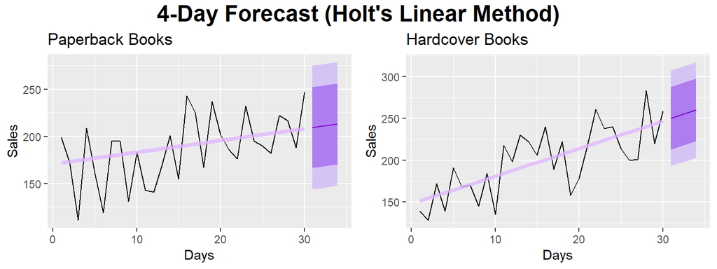

```r
pb_holt_plot <- autoplot(pb_holt, size=1, fcol="#7733ff") +
  autolayer(fitted(pb_holt), series="Fitted", alpha=.75, size=1.5, color="#e0b3ff") +
  labs(title="Paperback Books", y="Sales", x="Days")

hc_holt_plot <- autoplot(hc_holt, size=1, fcol="#7733ff") +
  autolayer(fitted(hc_holt), series="Fitted", alpha=.75, size=1.5, color="#e0b3ff") +
  labs(title="Hardcover Books", y="Sales", x="Days")

grid.arrange(pb_holt_plot, hc_holt_plot, ncol = 2,
             top=textGrob("4-Day Forecast (Holt's Linear Method)",
                          gp = gpar(fontface = "bold", cex = 1.5)))
```

## (b). Compare the RMSE measures of Holt’s method for the two series to those of simple exponential smoothing in the previous question. (Remember that Holt’s method is using one more parameter than SES.) Discuss the merits of the two forecasting methods for these data sets.

The RMSE from our Holt’s method are listed in the table below. We can compare the accuracy of this method to that of SES from question 7.5c. We find that the Holt method produced a lower error score for both paperback and hardcover books.

```r
#manual calculation
sqrt(mean(pb_holt$residuals^2))
sqrt(mean(hc_holt$residuals^2))

#caret package
RMSE(fitted(pb_holt), paperback)
RMSE(fitted(hc_holt), hardcover)
```

RMSE Values for Book Sales Forecast

|  | paperback | hardcover |
| --- | --- | --- |
| SES | 33.63769 | 31.93101 |
| Holt | 31.13692 | 27.19358 |

## (c). Compare the forecasts for the two series using both methods. Which do you think is best?

While Holt’s method provided better accuracy measures (RMSE), the 4-day point forecast from this method appears less reliable than the SES method. Holt’s forecast continues to rise and does not appear to take into account the seasonal fluctuations within our data. This is a known limitation of Holt’s linear method (without dampening) as the point forecasts follow an indefinite, constant trend.

[figure not shown]

```r
pb_series <- cbind("Data" = paperback,
                   "Fitted (SES)" = fitted(pb_ses),
                   "Fitted (Holt)"= fitted(pb_holt),
                   "Forecast (SES)" = pb_ses[["mean"]],
                   "Forecast (Holt)" = pb_holt[["mean"]])

hc_series <- cbind("Data" = paperback,
                   "Fitted (SES)" = fitted(hc_ses),
                   "Fitted (Holt)"= fitted(hc_holt),
                   "Forecast (SES)" = hc_ses[["mean"]],
                   "Forecast (Holt)" = hc_holt[["mean"]])

pb_series_plot <- autoplot(pb_series, size=1) +
  scale_color_manual(name = "", values=c("#000000", "#99b3ff", "#e0b3ff", "#0044cc", "#a31aff"))+
  labs(title="Paperback", x="Days", y="Sales")

hc_series_plot <- autoplot(hc_series, size=1) +
  scale_color_manual(name = "", values=c("#000000", "#99b3ff", "#e0b3ff", "#0044cc", "#a31aff"))+
  labs(title="Hardcover", x="Days", y="Sales")

grid_arrange_shared_legend(pb_series_plot,
                           hc_series_plot,
                           ncol = 2,
                           top=textGrob("4-Day Forecast Comparision of Book Sales",
                                        gp = gpar(fontface = "bold", cex = 1.5)),
                           position='bottom')
```

## (d). Calculate a 95% prediction interval for the first forecast for each series, using the RMSE values and assuming normal errors. Compare your intervals with those produced using `ses` and `holt`.

Prediction interverals were calculated and compared to R using the RMSE values of paperback and hardcover books from 7.6b. The intervals were also compared using `ses` and `holt` methods.

We found that our calculations produced slightly smaller prediction intervals than the one’s generated in R. Additionally, Holt’s method produced smaller prediction intervals overall for both the computational and R approach.

```r
# Paperback Calculation
pb_lower_ses <- pb_ses$mean[1]- 1.96*pb_rmse_ses
pb_upper_ses <- pb_ses$mean[1]+ 1.96*pb_rmse_ses

pb_lower_holt <- pb_holt$mean[1]- 1.96*pb_rmse_holt
pb_upper_holt <- pb_holt$mean[1]+ 1.96*pb_rmse_holt

# Hardcover Calculation
hc_lower_ses <- hc_ses$mean[1]- 1.96*hc_rmse_ses
hc_upper_ses <- hc_ses$mean[1]+ 1.96*hc_rmse_ses

hc_lower_holt <- hc_holt$mean[1]- 1.96*hc_rmse_holt
hc_upper_holt <- hc_holt$mean[1]+ 1.96*hc_rmse_holt

# R Paperback Intervals
pb_lower_sesR <- as.numeric(pb_ses$lower[1, "95%"])
pb_upper_sesR <- as.numeric(pb_ses$upper[1, "95%"])

pb_lower_holtR <- as.numeric(pb_holt$lower[1, "95%"])
pb_upper_holtR <- as.numeric(pb_holt$upper[1, "95%"])

# R Hardcover Intervals
hc_lower_sesR <- as.numeric(hc_ses$lower[1, "95%"])
hc_upper_sesR <- as.numeric(hc_ses$upper[1, "95%"])

hc_lower_holtR <- as.numeric(hc_holt$lower[1, "95%"])
hc_upper_holtR <- as.numeric(hc_holt$upper[1, "95%"])
```

Comparison of 95% Confidence Interval Calculations for Book Sales Forecast

|  | Paperback Computed | Paperback R |  | Hardcover Computed | Hardcover R |
| --- | --- | --- | --- | --- | --- |
| **Simple Exponential Smoothing** |  |  |  |  |  |
| Lower | 141.179798900711 | 138.867024106993 |  | 176.97530263223 | 174.779870851487 |
| Upper | 273.039531089726 | 275.352305883445 |  | 302.144881371293 | 304.340313152036 |
| **Holt’s Linear Method** |  |  |  |  |  |
| Lower | 148.438396409231 | 143.912985820256 |  | 196.874459367927 | 192.922170771941 |
| Upper | 270.495134632871 | 275.020545221845 |  | 303.473285056784 | 307.42557365277 |

# 7.10: For this exercise use data set `ukcars`, the quarterly UK passenger vehicle production data from 1977Q1-2005Q1.

## (a). Plot the data and describe the main features of the series.

There appears to be a general upward trend in production from 1982-Q3 to 2000-Q1. The overall time series shows fluxuations between years suggesting an underlying seasonality component.

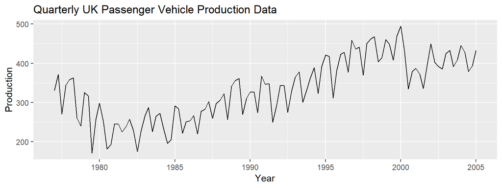

```r
ukcdata <- window(ukcars, start=1977, end=2005)
autoplot(ukcdata) +
  labs(title = "Quarterly UK Passenger Vehicle Production Data", y="Production", x="Year")
```

## (b). Decompose the series using STL and obtain the seasonally adjusted data.

### STL Decomposition

Through decomposition, we can confirm the overall increasing trend described in part (a). There are consistant seasonal fluxations which can we can futher evaluate using a seasonal plot.

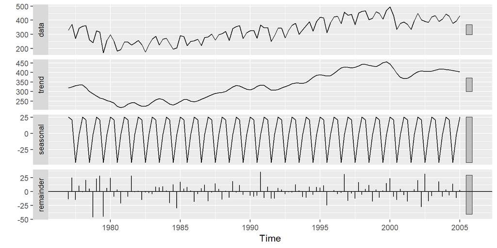

```r
ukc_stl <- stl(ukcdata, s.window = "periodic")
autoplot(ukc_stl)
```

### Seasonal Plots

The subseries plot further confirms our seasonal pattern and shows that the smallest pattern changes occur between Q1-Q2. The decreases and increases between Q2-Q4 are much more distingushable.

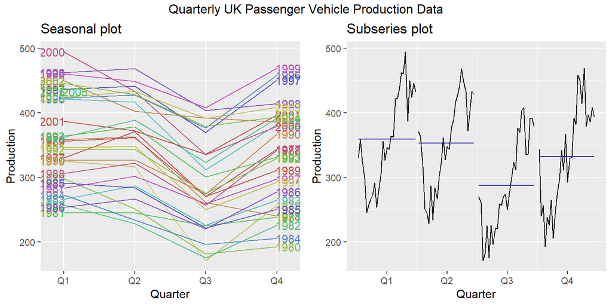

```r
ukc_s_plot <- ggseasonplot(ukcdata, year.labels=TRUE, year.labels.left=T, col=rainbow(12,s = 0.6, v = 0.75)) +
  labs(title="Seasonal plot", y="Production")

ukc_ss_plot <- ggsubseriesplot(ukcdata) +
  labs(title="Subseries plot", y="Production")

grid.arrange(ukc_s_plot,
             ukc_ss_plot,
             ncol = 2,
             top="Quarterly UK Passenger Vehicle Production Data")
```

We can capture the seasonal component observed in the data and control for the changes overtime using a seasonal adjustment. We compared the seasonally adjusted data to the observed data for `ukcars` below:

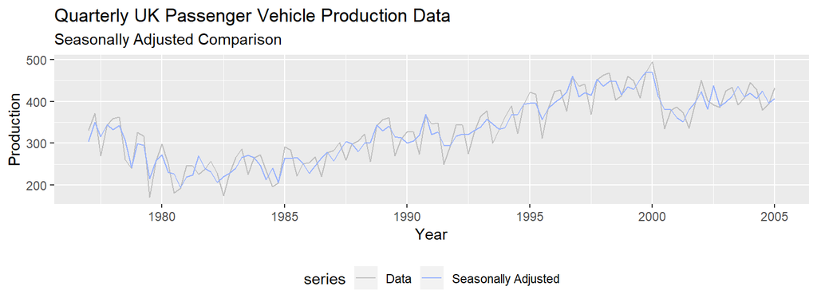

```r
ukc_seas <- seasadj(ukc_stl)

autoplot(ukcdata, series="Data") +
  autolayer(ukc_seas, series="Seasonally Adjusted") +
   labs(title = "Quarterly UK Passenger Vehicle Production Data",
       subtitle = "Seasonally Adjusted Comparison",
       x = "Year",
       y = "Production")+
  scale_colour_manual(values=c("#bfbfbf","#99b3ff"),
                      breaks=c("Data","Seasonally Adjusted","Trend")) +
  theme(legend.position="bottom")
```

## (c). Forecast the next two years of the series using an additive damped trend method applied to the seasonally adjusted data. (This can be done in one step using `stlf()` with arguments `etsmodel="AAN"`, `damped=TRUE`.)

### Summary

```r
ukc_stlf1 <- stlf(ukcdata, s.window = "periodic", etsmodel="AAN", damped=TRUE, h=8)
summary(ukc_stlf1)
```

```
##
## Forecast method: STL +  ETS(A,Ad,N)
##
## Model Information:
## ETS(A,Ad,N)
##
## Call:
##  ets(y = x, model = etsmodel, damped = TRUE, allow.multiplicative.trend = allow.multiplicative.trend)
##
##   Smoothing parameters:
##     alpha = 0.5716
##     beta  = 1e-04
##     phi   = 0.9135
##
##   Initial states:
##     l = 346.5048
##     b = -8.9409
##
##   sigma:  25.7357
##
##      AIC     AICc      BIC
## 1275.101 1275.894 1291.466
##
## Error measures:
##                    ME     RMSE      MAE       MPE     MAPE      MASE
## Training set 2.385752 25.15986 20.51581 0.2441499 6.688313 0.6686003
##                    ACF1
## Training set 0.03574596
##
## Forecasts:
##         Point Forecast    Lo 80    Hi 80    Lo 95    Hi 95
## 2005 Q2       406.4679 373.4863 439.4495 356.0269 456.9089
## 2005 Q3       406.4673 368.4766 444.4580 348.3655 464.5691
## 2005 Q4       406.4668 364.0533 448.8804 341.6009 471.3327
## 2006 Q1       406.4664 360.0485 452.8842 335.4764 477.4563
## 2006 Q2       406.4660 356.3620 456.5700 329.8385 483.0934
## 2006 Q3       406.4656 352.9279 460.0033 324.5867 488.3444
## 2006 Q4       406.4652 349.7005 463.2299 319.6511 493.2794
## 2007 Q1       406.4649 346.6465 466.2834 314.9805 497.9493
```

### Plot

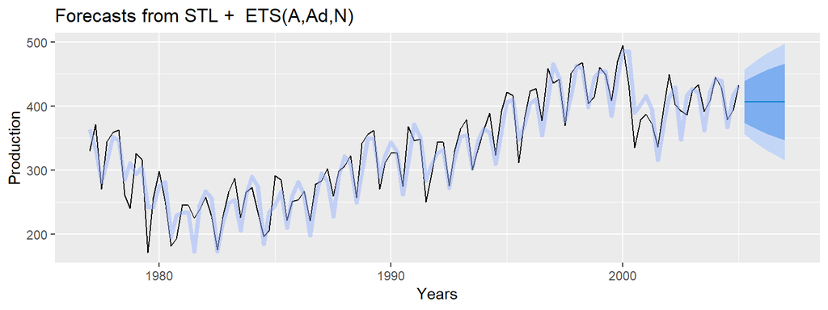

```r
autoplot(ukc_stlf1, size=1.25, fcol="#0044cc") +
  autolayer(fitted(ukc_stlf1), series="Fitted", alpha=.5, size=1.5, color="#99b3ff") +
  labs(y="Production", x="Years")
```

## (d). Forecast the next two years of the series using Holt’s linear method applied to the seasonally adjusted data (as before but with damped=FALSE).

### Summary

```r
ukc_stlf2 <- stlf(ukcdata, s.window = "periodic", etsmodel="AAN", damped=FALSE, h=8)
summary(ukc_stlf2)
```

```
##
## Forecast method: STL +  ETS(A,A,N)
##
## Model Information:
## ETS(A,A,N)
##
## Call:
##  ets(y = x, model = etsmodel, damped = FALSE, allow.multiplicative.trend = allow.multiplicative.trend)
##
##   Smoothing parameters:
##     alpha = 0.6049
##     beta  = 1e-04
##
##   Initial states:
##     l = 334.5746
##     b = 0.8353
##
##   sigma:  25.7197
##
##      AIC     AICc      BIC
## 1274.003 1274.563 1287.640
##
## Error measures:
##                      ME     RMSE      MAE        MPE     MAPE      MASE
## Training set -0.3111054 25.26041 20.10955 -0.6755072 6.621583 0.6553605
##                    ACF1
## Training set 0.03183711
##
## Forecasts:
##         Point Forecast    Lo 80    Hi 80    Lo 95    Hi 95
## 2005 Q2       407.6326 374.6715 440.5938 357.2229 458.0424
## 2005 Q3       408.4644 369.9399 446.9889 349.5463 467.3825
## 2005 Q4       409.2962 365.9146 452.6778 342.9497 475.6426
## 2006 Q1       410.1280 362.3794 457.8765 337.1029 483.1531
## 2006 Q2       410.9598 359.2102 462.7093 331.8157 490.1039
## 2006 Q3       411.7915 356.3277 467.2554 326.9669 496.6162
## 2006 Q4       412.6233 353.6776 471.5690 322.4737 502.7730
## 2007 Q1       413.4551 351.2210 475.6892 318.2763 508.6339
```

### Plot

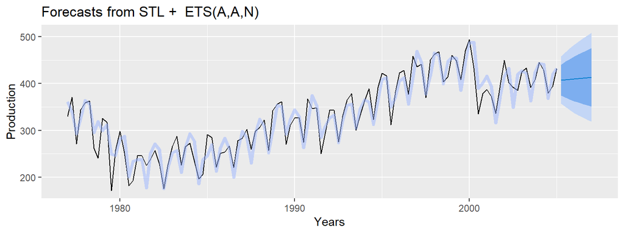

```r
autoplot(ukc_stlf2, size=1.25, fcol="#0044cc") +
  autolayer(fitted(ukc_stlf2), series="Fitted", alpha=.5, size=1.5, color="#99b3ff") +
  labs(y="Production", x="Years")
```

## (e). Now use ets() to choose a seasonal model for the data.

### Summary

```r
ukc_ets <- ets(ukcdata)
ukc_ets_fc <- ukc_ets %>% forecast(h=8)

summary(ukc_ets)
```

```
## ETS(A,N,A)
##
## Call:
##  ets(y = ukcdata)
##
##   Smoothing parameters:
##     alpha = 0.6199
##     gamma = 1e-04
##
##   Initial states:
##     l = 314.2568
##     s = -1.7579 -44.9601 21.1956 25.5223
##
##   sigma:  25.9302
##
##      AIC     AICc      BIC
## 1277.752 1278.819 1296.844
##
## Training set error measures:
##                    ME     RMSE      MAE        MPE     MAPE      MASE
## Training set 1.313884 25.23244 20.17907 -0.1570979 6.629003 0.6576259
##                    ACF1
## Training set 0.02573334
```

```r
ukc_ets_fc
```

```
##         Point Forecast    Lo 80    Hi 80    Lo 95    Hi 95
## 2005 Q2       427.4885 394.2576 460.7195 376.6662 478.3109
## 2005 Q3       361.3329 322.2353 400.4305 301.5383 421.1275
## 2005 Q4       404.5358 360.3437 448.7280 336.9497 472.1219
## 2006 Q1       431.8154 383.0568 480.5741 357.2455 506.3854
## 2006 Q2       427.4885 374.5571 480.4200 346.5369 508.4401
## 2006 Q3       361.3329 304.5345 418.1313 274.4672 448.1986
## 2006 Q4       404.5358 344.1174 464.9542 312.1338 496.9378
## 2007 Q1       431.8154 367.9809 495.6500 334.1890 529.4419
```

### Plot

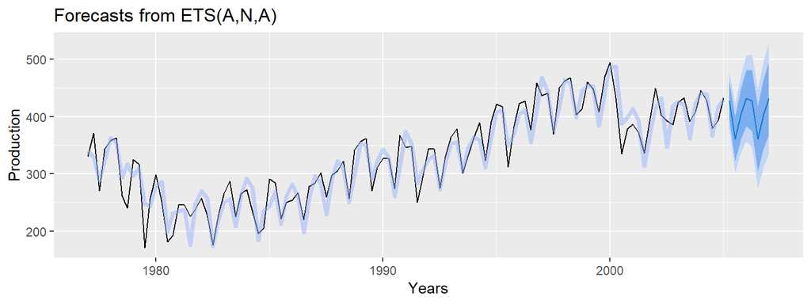

```r
autoplot(ukc_ets_fc, size=1.25, fcol="#0044cc") +
  autolayer(fitted(ukc_ets), series="Fitted", alpha=.5, size=1.5, color="#99b3ff") +
  labs(y="Production", x="Years")
```

## (f). Compare the RMSE of the ETS model with the RMSE of the models you obtained using STL decompositions. Which gives the better in-sample fits?

Our STL decomponsition, using additive damped trend method with no seasonal components ($A, A_d, N$), produced the best in-sample fit. This model provided us with the lowest RMSE, suggesting the highest degree of accuracy between our predicted and observed data. We should note, however, there is a very small variation in RMSE between all STL and ETS models.

RMSE Comparison Between STL and ETS Models

|  | RMSE |
| --- | --- |
| **STL** |  |
| A, Ad, N | 25.15986 |
| A, A, N | 25.26041 |
| **ETS** |  |
| A, N, A | 25.23244 |

## (g). Compare the forecasts from the three approaches? Which seems most reasonable?

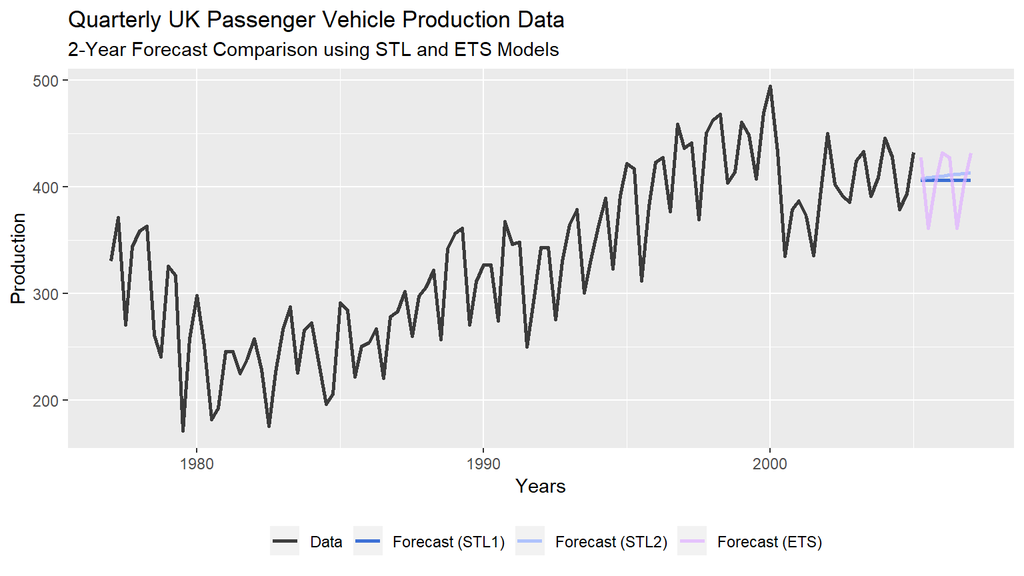

```r
ukc_series <- cbind("Data" = ukcdata,
                   "Forecast (STL1)" = ukc_stlf1[["mean"]],
                   "Forecast (STL2)" = ukc_stlf2[["mean"]],
                   "Forecast (ETS)" = ukc_ets_fc[["mean"]])

autoplot(ukc_series, size=1, alpha=.75) +
  scale_color_manual(name = "",
                     values=c("#000000", "#0044cc", "#99b3ff", "#e0b3ff"))+
  labs(title = "Quarterly UK Passenger Vehicle Production Data",
       subtitle = "2-Year Forecast Comparison using STL and ETS Models",
       x="Years",
       y="Production") +
  theme(legend.position="bottom")
```

## (h). Check the residuals of your preferred model.

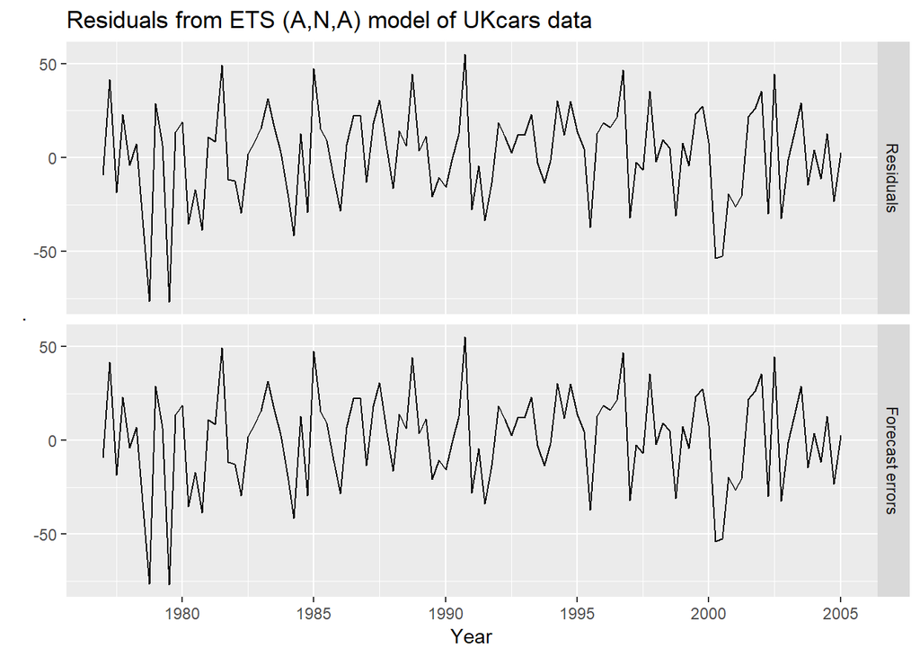

```r
cbind('Residuals' = residuals(ukc_ets),
      'Forecast errors' = residuals(ukc_ets, type='innovation')) %>%
  autoplot(facet=TRUE) +
  labs(title="Residuals from ETS (A,N,A) model of UKcars data", x="Year")
```